# Exploratory Data Analysis of Red Wine by Simon Zhang

**Introduction**: This report explores a dataset containing quality (score between 0 - 10) and physicochemical attributes for approximately 1,600 red wines.

### Univariate Plots Section

Let’s take a look at the basic dimensions, structure, and summary of the dataset.

```
## [1] 1599   13
```

```
## 'data.frame':    1599 obs. of  13 variables:
##  $ X                   : int  1 2 3 4 5 6 7 8 9 10 ...
##  $ fixed.acidity       : num  7.4 7.8 7.8 11.2 7.4 7.4 7.9 7.3 7.8 7.5 ...
##  $ volatile.acidity    : num  0.7 0.88 0.76 0.28 0.7 0.66 0.6 0.65 0.58 0.5 ...
##  $ citric.acid         : num  0 0 0.04 0.56 0 0 0.06 0 0.02 0.36 ...
##  $ residual.sugar      : num  1.9 2.6 2.3 1.9 1.9 1.8 1.6 1.2 2 6.1 ...
##  $ chlorides           : num  0.076 0.098 0.092 0.075 0.076 0.075 0.069 0.065 0.073 0.071 ...
##  $ free.sulfur.dioxide : num  11 25 15 17 11 13 15 15 9 17 ...
##  $ total.sulfur.dioxide: num  34 67 54 60 34 40 59 21 18 102 ...
##  $ density             : num  0.998 0.997 0.997 0.998 0.998 ...
##  $ pH                  : num  3.51 3.2 3.26 3.16 3.51 3.51 3.3 3.39 3.36 3.35 ...
##  $ sulphates           : num  0.56 0.68 0.65 0.58 0.56 0.56 0.46 0.47 0.57 0.8 ...
##  $ alcohol             : num  9.4 9.8 9.8 9.8 9.4 9.4 9.4 10 9.5 10.5 ...
##  $ quality             : int  5 5 5 6 5 5 5 7 7 5 ...
```

```
##        X          fixed.acidity   volatile.acidity  citric.acid
##  Min.   :   1.0   Min.   : 4.60   Min.   :0.1200   Min.   :0.000
##  1st Qu.: 400.5   1st Qu.: 7.10   1st Qu.:0.3900   1st Qu.:0.090
##  Median : 800.0   Median : 7.90   Median :0.5200   Median :0.260
##  Mean   : 800.0   Mean   : 8.32   Mean   :0.5278   Mean   :0.271
##  3rd Qu.:1199.5   3rd Qu.: 9.20   3rd Qu.:0.6400   3rd Qu.:0.420
##  Max.   :1599.0   Max.   :15.90   Max.   :1.5800   Max.   :1.000
##  residual.sugar     chlorides       free.sulfur.dioxide
##  Min.   : 0.900   Min.   :0.01200   Min.   : 1.00
##  1st Qu.: 1.900   1st Qu.:0.07000   1st Qu.: 7.00
##  Median : 2.200   Median :0.07900   Median :14.00
##  Mean   : 2.539   Mean   :0.08747   Mean   :15.87
##  3rd Qu.: 2.600   3rd Qu.:0.09000   3rd Qu.:21.00
##  Max.   :15.500   Max.   :0.61100   Max.   :72.00
##  total.sulfur.dioxide    density             pH          sulphates
##  Min.   :  6.00       Min.   :0.9901   Min.   :2.740   Min.   :0.3300
##  1st Qu.: 22.00       1st Qu.:0.9956   1st Qu.:3.210   1st Qu.:0.5500
##  Median : 38.00       Median :0.9968   Median :3.310   Median :0.6200
##  Mean   : 46.47       Mean   :0.9967   Mean   :3.311   Mean   :0.6581
##  3rd Qu.: 62.00       3rd Qu.:0.9978   3rd Qu.:3.400   3rd Qu.:0.7300
##  Max.   :289.00       Max.   :1.0037   Max.   :4.010   Max.   :2.0000
##     alcohol         quality
##  Min.   : 8.40   Min.   :3.000
##  1st Qu.: 9.50   1st Qu.:5.000
##  Median :10.20   Median :6.000
##  Mean   :10.42   Mean   :5.636
##  3rd Qu.:11.10   3rd Qu.:6.000
##  Max.   :14.90   Max.   :8.000
```

The dataset consists of 13 variables with 1599 observations.

Let’s take a look at the quality distribution.

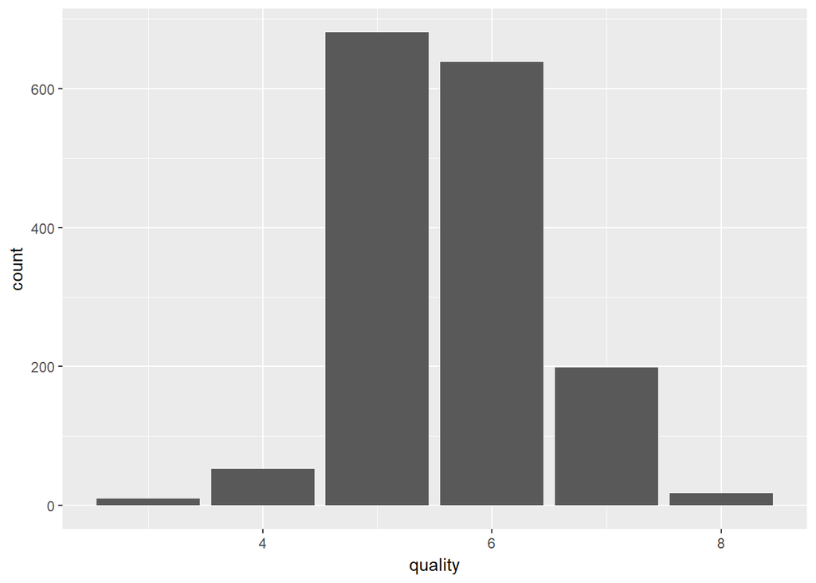

```
##
##   3   4   5   6   7   8
##  10  53 681 638 199  18
```

Quality looks relatively close to a normal distribution with most values in the middle, however, there’s more higher quality wine than lower quality wine in this dataset. Most wines have are at 5 or 6. There aren’t any wines with 1, 2, or 9 ratings for quality.

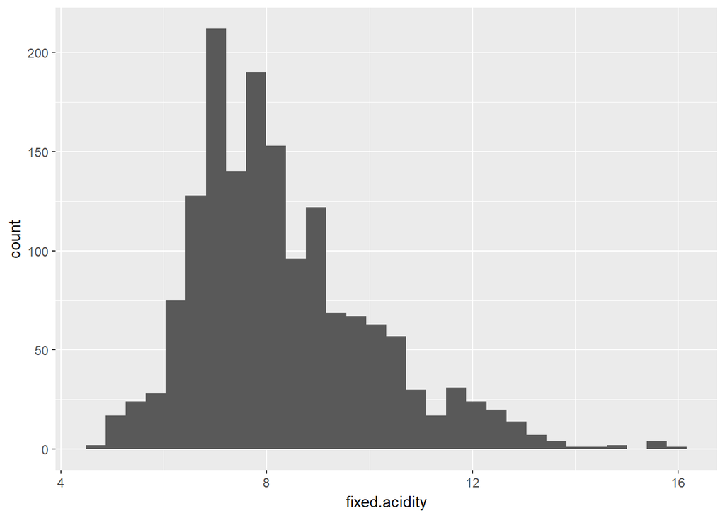

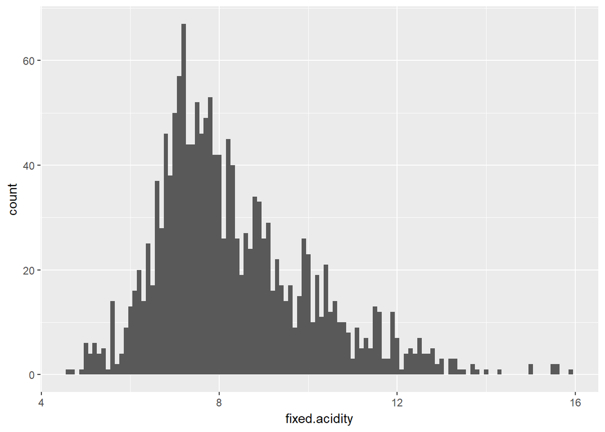

I took a look at fixed acidity. I lowered the binwidth just to make see if there was bimodality present or not. Doesn’t seem bimodal but it is skewed to the right a little bit.

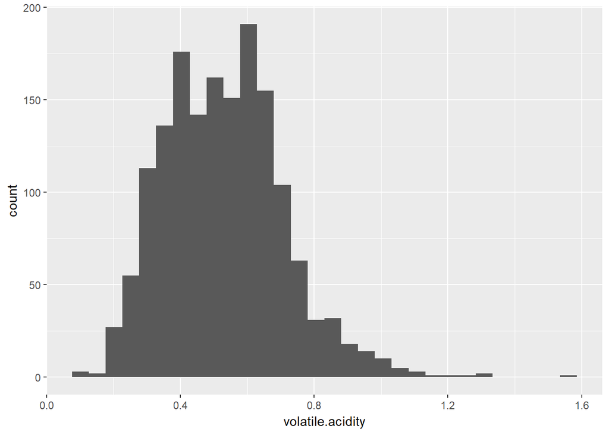

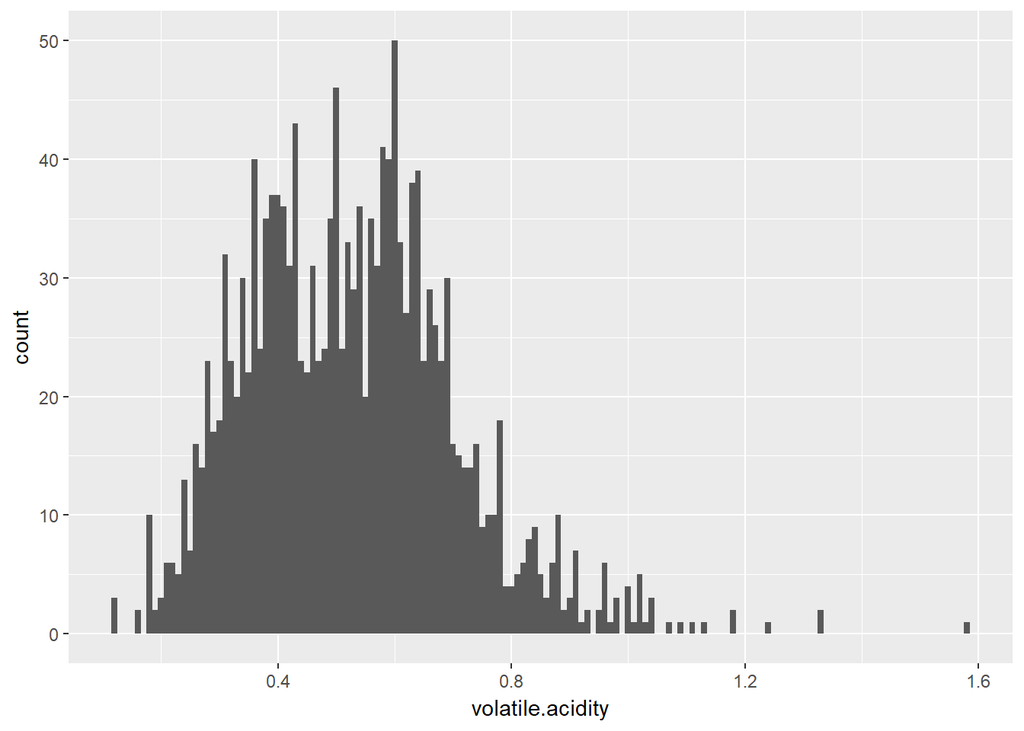

Next I looked at volatile acidity. I also lowered the binwidth to see if there was any bimodality. It seems that there is a bit of bimodality (possibly trimodality) with a peak at around .4 and another at around .62. Distribution is also skewed to right a bit.

```
##    Min. 1st Qu.  Median    Mean 3rd Qu.    Max.
## 0.01348 0.04405 0.06569 0.06706 0.08581 0.20800
```

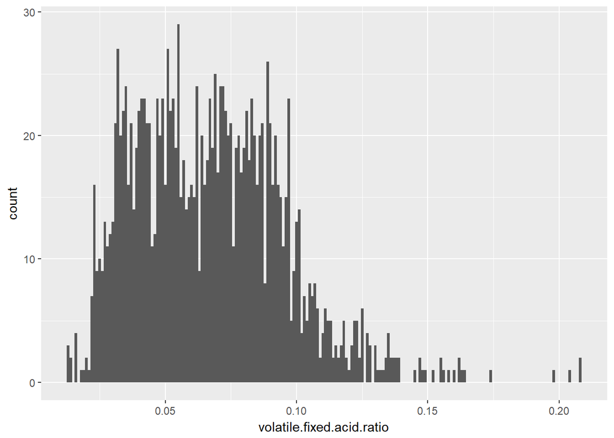

I wanted to take a look at the ratio of volatile to fixed acidity just out of curiousity to see if anything interesting came up. It seems like most of the values lie between .04 and .1 with a few outliers as far out as .2.

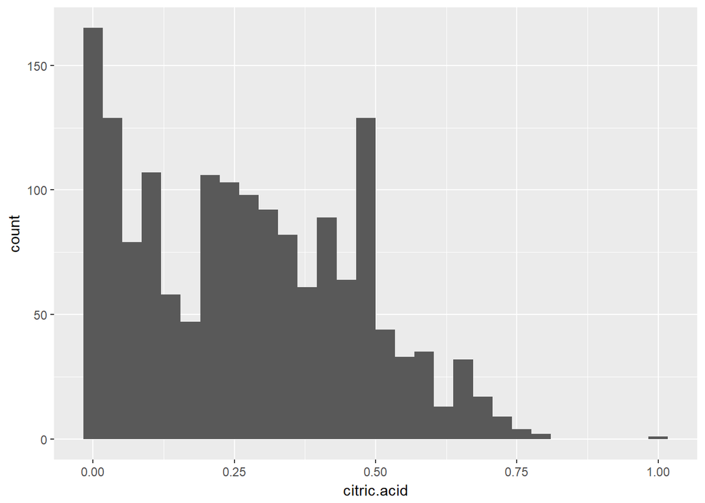

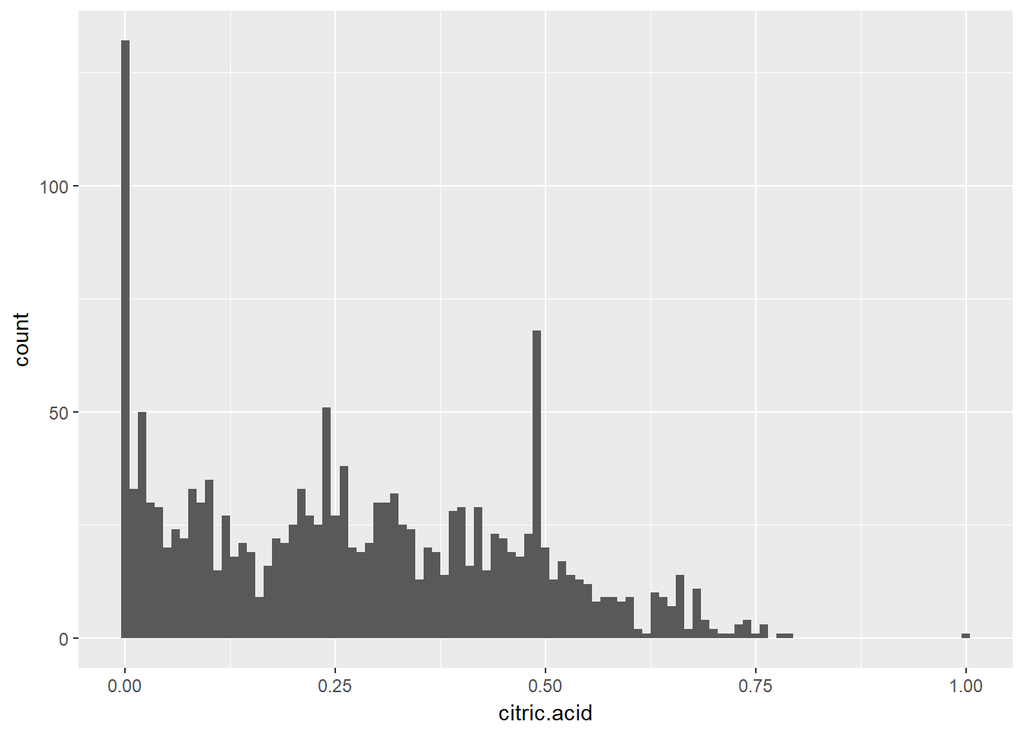

```
##
##    0 0.01 0.02 0.03 0.04 0.05 0.06 0.07 0.08 0.09  0.1 0.11 0.12 0.13 0.14
##  132   33   50   30   29   20   24   22   33   30   35   15   27   18   21
## 0.15 0.16 0.17 0.18 0.19  0.2 0.21 0.22 0.23 0.24 0.25 0.26 0.27 0.28 0.29
##   19    9   16   22   21   25   33   27   25   51   27   38   20   19   21
##  0.3 0.31 0.32 0.33 0.34 0.35 0.36 0.37 0.38 0.39  0.4 0.41 0.42 0.43 0.44
##   30   30   32   25   24   13   20   19   14   28   29   16   29   15   23
## 0.45 0.46 0.47 0.48 0.49  0.5 0.51 0.52 0.53 0.54 0.55 0.56 0.57 0.58 0.59
##   22   19   18   23   68   20   13   17   14   13   12    8    9    9    8
##  0.6 0.61 0.62 0.63 0.64 0.65 0.66 0.67 0.68 0.69  0.7 0.71 0.72 0.73 0.74
##    9    2    1   10    9    7   14    2   11    4    2    1    1    3    4
## 0.75 0.76 0.78 0.79    1
##    1    3    1    1    1
```

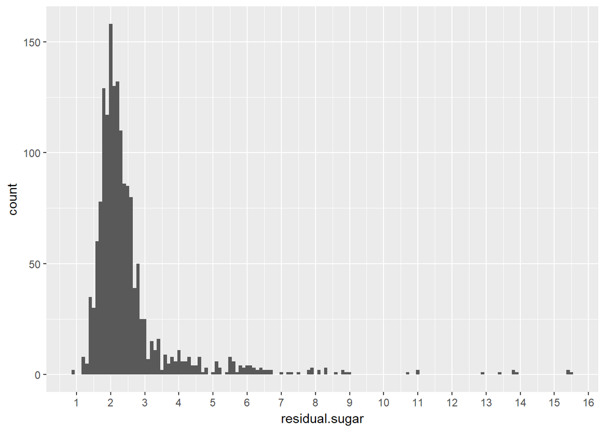

Residual sugar peaks at at 2 with most between 1.5 and 3. Skewed to the right with few outliers really far out.

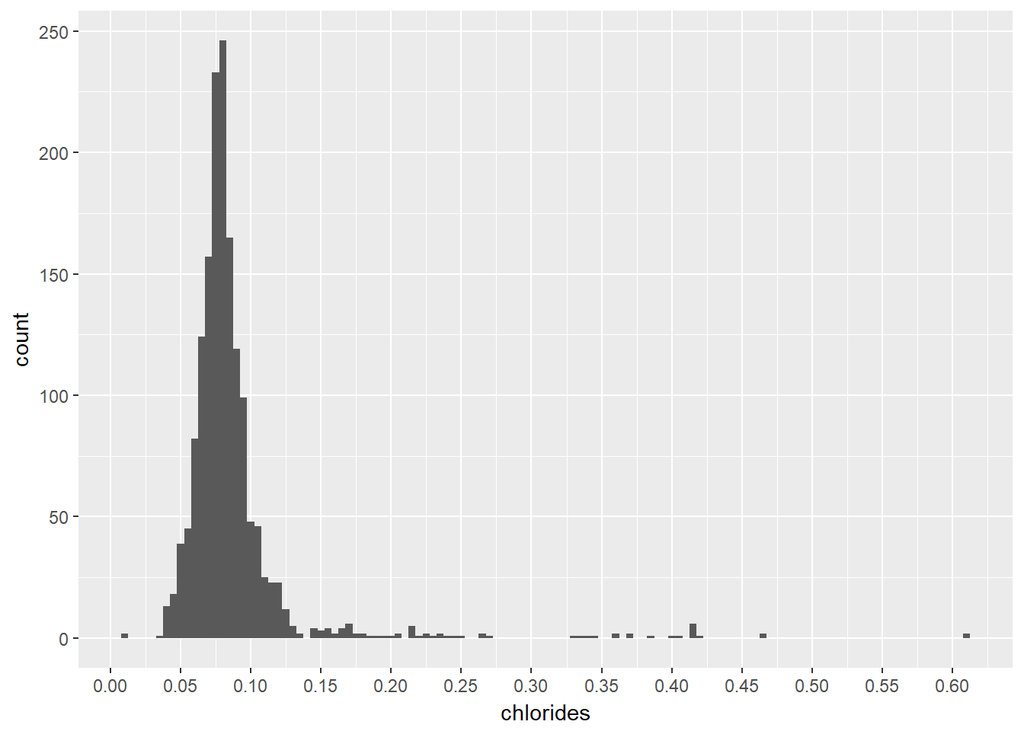

Chlorides (salt) content is mostly contained between .05 and .125 with a few outliers as well.

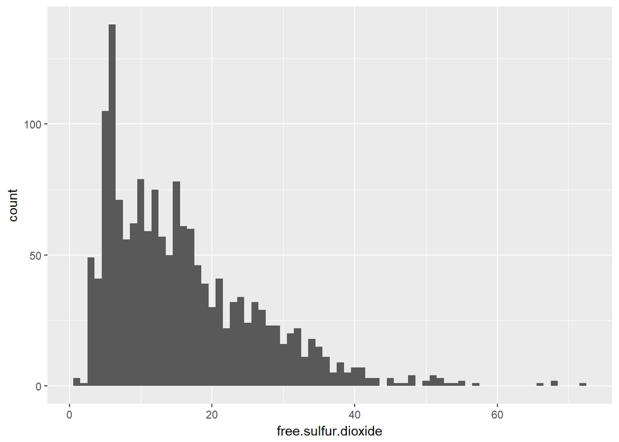

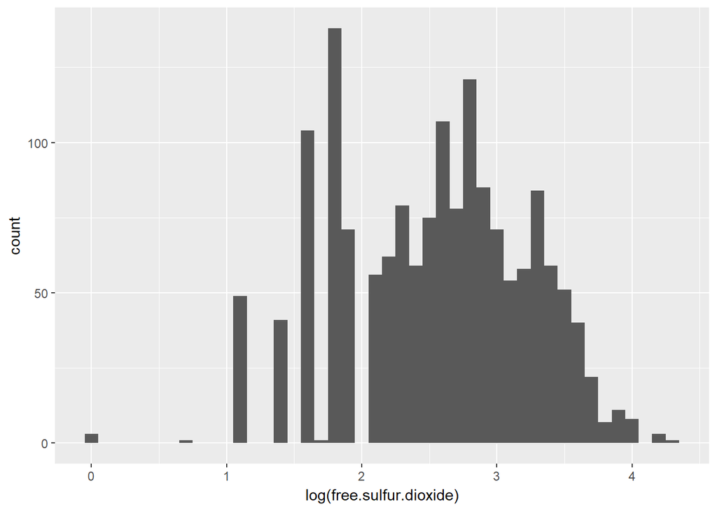

```
##
##  5  6  7
## 10  6  2
```

Free sulfur dioxide is really skewed to the right. High peak around 6 mg/dm^3 and goes down slowly with most wines having less than 40 mg/dm^3. I performed a log transformation to understand the distributio a little better.

In the dataset description it says that at free S02 levels more than 50 ppm, it would be evident in the nose and taste. I created a subset of the data and looked at the quality of wines with free SO2 >= 50 ppm. There seems to be a negative relationship; however, there is so little data in this subset that its hard to be certain of any strong relationships.

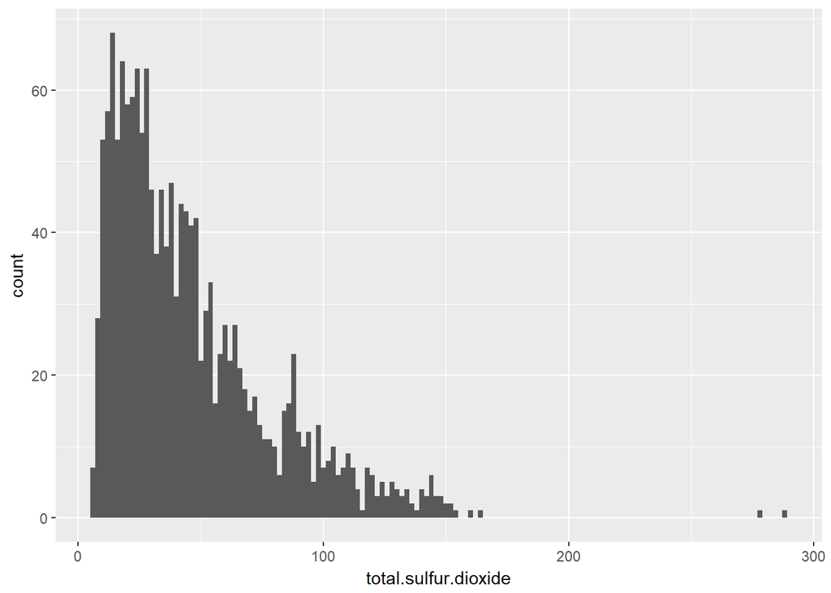

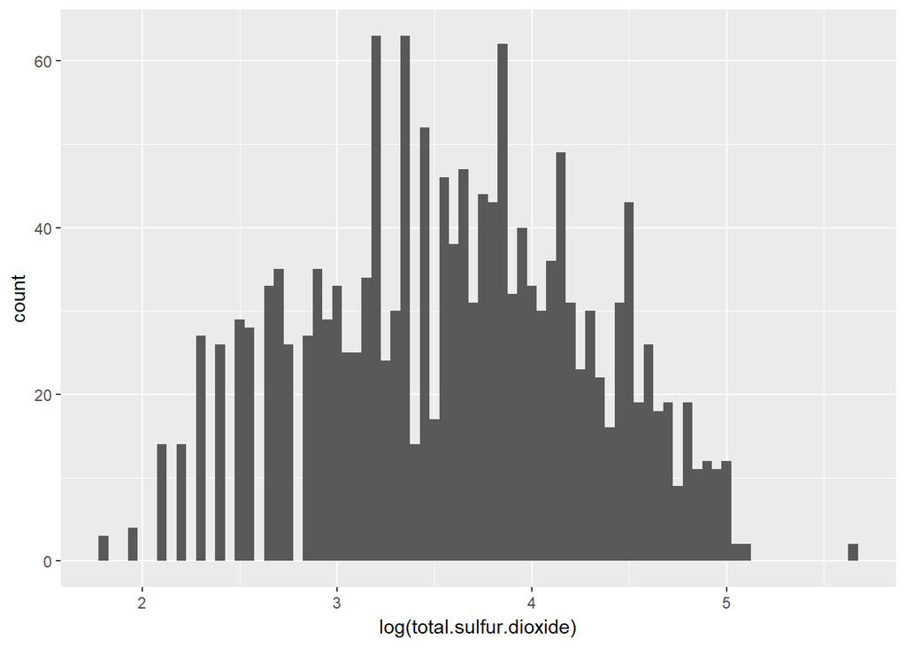

```
##    Min. 1st Qu.  Median    Mean 3rd Qu.    Max.
##    6.00   22.00   38.00   46.47   62.00  289.00
```

Total sulfur dioxide content seems to be similar to the free sulfur dioxide histogram. Heavily skewed to the right with none at 0 mg/dm^3 but most less than 100 mg/dm^3. I performed a log transformation on total sulfur dioxide as well and it distribution seems more normal now.

I also wanted to look ratio of free to total sulfur dioxide. The median is 14 mg/dm^3 free to 38 mg/dm^3 total.

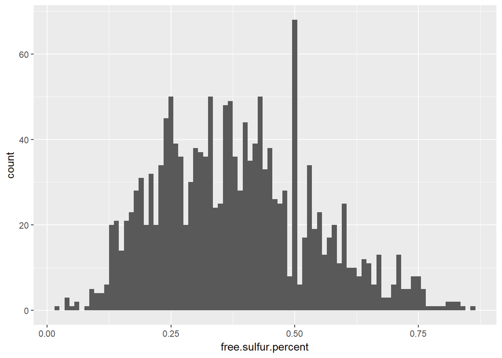

```
##    Min. 1st Qu.  Median    Mean 3rd Qu.    Max.
## 0.02273 0.25926 0.37500 0.38231 0.48485 0.85714
```

I plotted the percent of free sulfur dioxide. It seems like there is a spike in the histogram at .5(50%). Seems like most free sulfur dioxide percentage lies within approximately .26 and .48.

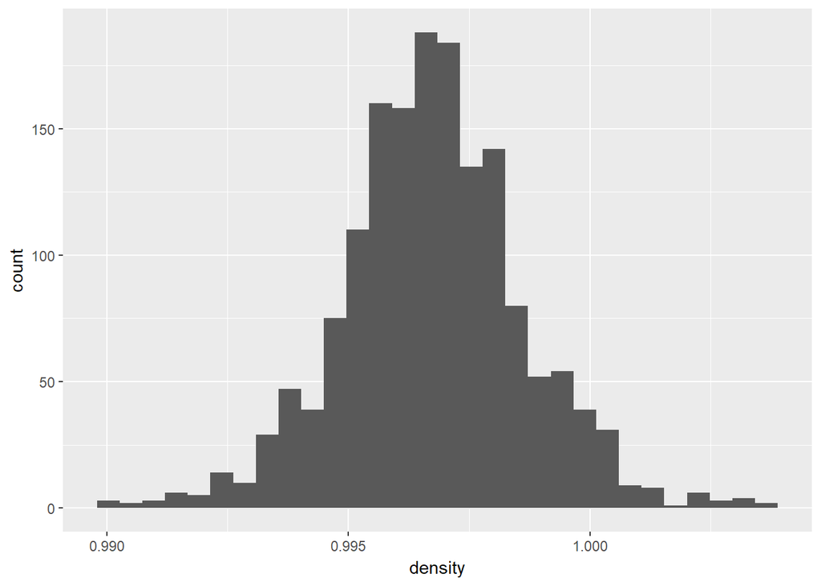

The density of red wine seems to be pretty normal in terms of distribution and most wines have densities between .993 g/cm^3 and 1 g/cm^3.

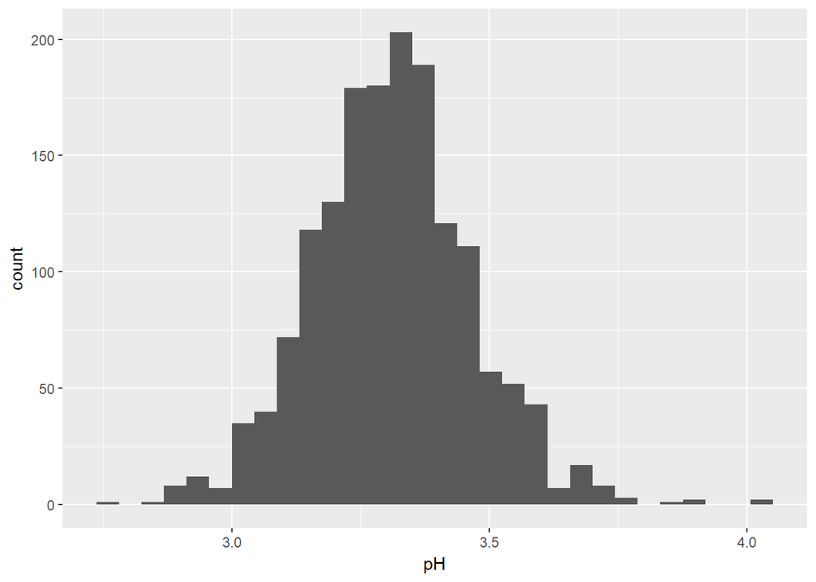

pH level seems pretty normally distributed like density with most pH values between approximately 3 and 3.6.

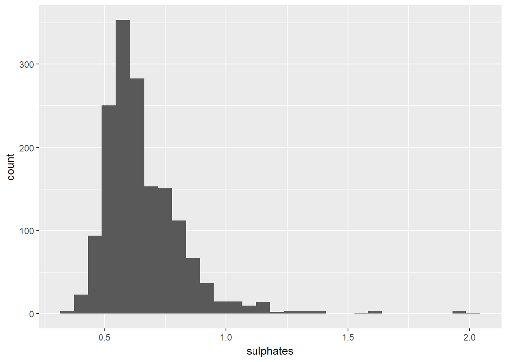

Most sulphate values are between .5 g/dm^3 and .9 g/dm^3. The distribution is skewed to the right.

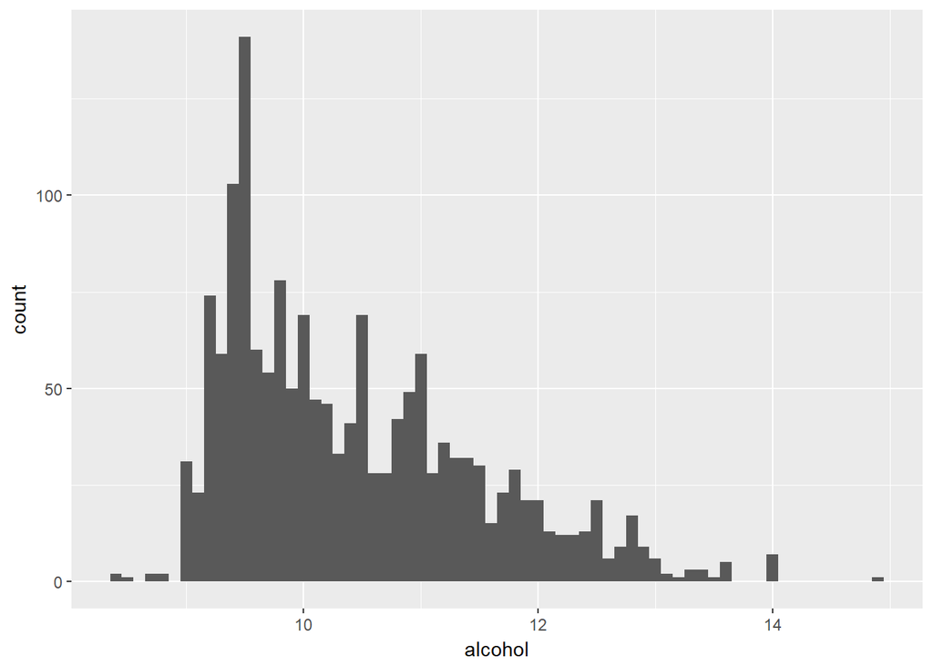

The distribution of alcohol content is skewed to the right with a peak around 9.5%. Most values range between 9% and 13% alcohol.

### Univariate Analysis

##### What is the structure of your dataset?

There are 1599 observations with 13 variables (X, fixed acidity, volatile acidity, citric acid, residual sugar, chlorides, free sulfur dioxide, total sulfur dioxide, density, pH, sulphates, alcohol, and quality). All variables are numeric values with X (observation number) and quality as integars.

##### What is/are the main feature(s) of interest in your dataset?

I’d like to know how each of the features affect the quality of the wine, however, I think that citric acid, free and total sulfur dioxide, volatile acidity, and alcohol are key variables in predicting the quality of the wine.

##### What other features in the dataset do you think will help support your investigation into your feature(s) of interest?

Residual sugar and chloride can both be looked into as well. I’d like to take a look at all the variables not mentioned above since I don’t know much about red wine and may discover some more interesting features about these variables than just what I’ve found in the histograms.

##### Did you create any new variables from existing variables in the dataset?

I created a new variable called free.sulfur.percent which is free sulfur dioxide divided by total sulfur dioxide to see if relative amounts of free sulfur dioxide has anything to do with the quality of the wine.

I also created a variable for volatile to fixed acidity ratio by dividing volatile by fixed acidity just to see if I could find some trends there; however, nothing obvious stuck out to me.

##### Of the features you investigated, were there any unusual distributions? Did you perform any operations on the data to tidy, adjust, or change the form of the data? If so, why did you do this?

Citric acid seemed to have an interesting distribution with a lot of values at 0 and also seems to be multi-modal.

I did perform a log transformations of both free and total sulfur dioxide since the plots were so skewed to the right to better understand the distribution. It made the distribution more normal, however, when I decreased the binwidth to a certain level it no changed the distribution from normal. At the moment, I’m not certain a log transformation is needed. I will continue to explore.

### Bivariate Plots Section

```
##                           fixed.acidity volatile.acidity citric.acid
## fixed.acidity                     1.000           -0.256       0.672
## volatile.acidity                 -0.256            1.000      -0.552
## citric.acid                       0.672           -0.552       1.000
## residual.sugar                    0.115            0.002       0.144
## chlorides                         0.094            0.061       0.204
## free.sulfur.dioxide              -0.154           -0.011      -0.061
## total.sulfur.dioxide             -0.113            0.076       0.036
## density                           0.668            0.022       0.365
## pH                               -0.683            0.235      -0.542
## sulphates                         0.183           -0.261       0.313
## alcohol                          -0.062           -0.202       0.110
## quality                           0.124           -0.391       0.226
## volatile.fixed.acid.ratio        -0.609            0.897      -0.715
## free.sulfur.percent              -0.131           -0.073      -0.167
##                           residual.sugar chlorides free.sulfur.dioxide
## fixed.acidity                      0.115     0.094              -0.154
## volatile.acidity                   0.002     0.061              -0.011
## citric.acid                        0.144     0.204              -0.061
## residual.sugar                     1.000     0.056               0.187
## chlorides                          0.056     1.000               0.006
## free.sulfur.dioxide                0.187     0.006               1.000
## total.sulfur.dioxide               0.203     0.047               0.668
## density                            0.355     0.201              -0.022
## pH                                -0.086    -0.265               0.070
## sulphates                          0.006     0.371               0.052
## alcohol                            0.042    -0.221              -0.069
## quality                            0.014    -0.129              -0.051
## volatile.fixed.acid.ratio         -0.050    -0.010               0.040
## free.sulfur.percent               -0.071    -0.105               0.327
##                           total.sulfur.dioxide density     pH sulphates
## fixed.acidity                           -0.113   0.668 -0.683     0.183
## volatile.acidity                         0.076   0.022  0.235    -0.261
## citric.acid                              0.036   0.365 -0.542     0.313
## residual.sugar                           0.203   0.355 -0.086     0.006
## chlorides                                0.047   0.201 -0.265     0.371
## free.sulfur.dioxide                      0.668  -0.022  0.070     0.052
## total.sulfur.dioxide                     1.000   0.071 -0.066     0.043
## density                                  0.071   1.000 -0.342     0.149
## pH                                      -0.066  -0.342  1.000    -0.197
```

[output cut: 20 more lines]

```
##                           free.sulfur.percent
## fixed.acidity                          -0.131
## volatile.acidity                       -0.073
## citric.acid                            -0.167
## residual.sugar                         -0.071
## chlorides                              -0.105
## free.sulfur.dioxide                     0.327
## total.sulfur.dioxide                   -0.371
## density                                -0.265
## pH                                      0.185
## sulphates                              -0.010
## alcohol                                 0.246
## quality                                 0.194
## volatile.fixed.acid.ratio               0.017
## free.sulfur.percent                     1.000
```

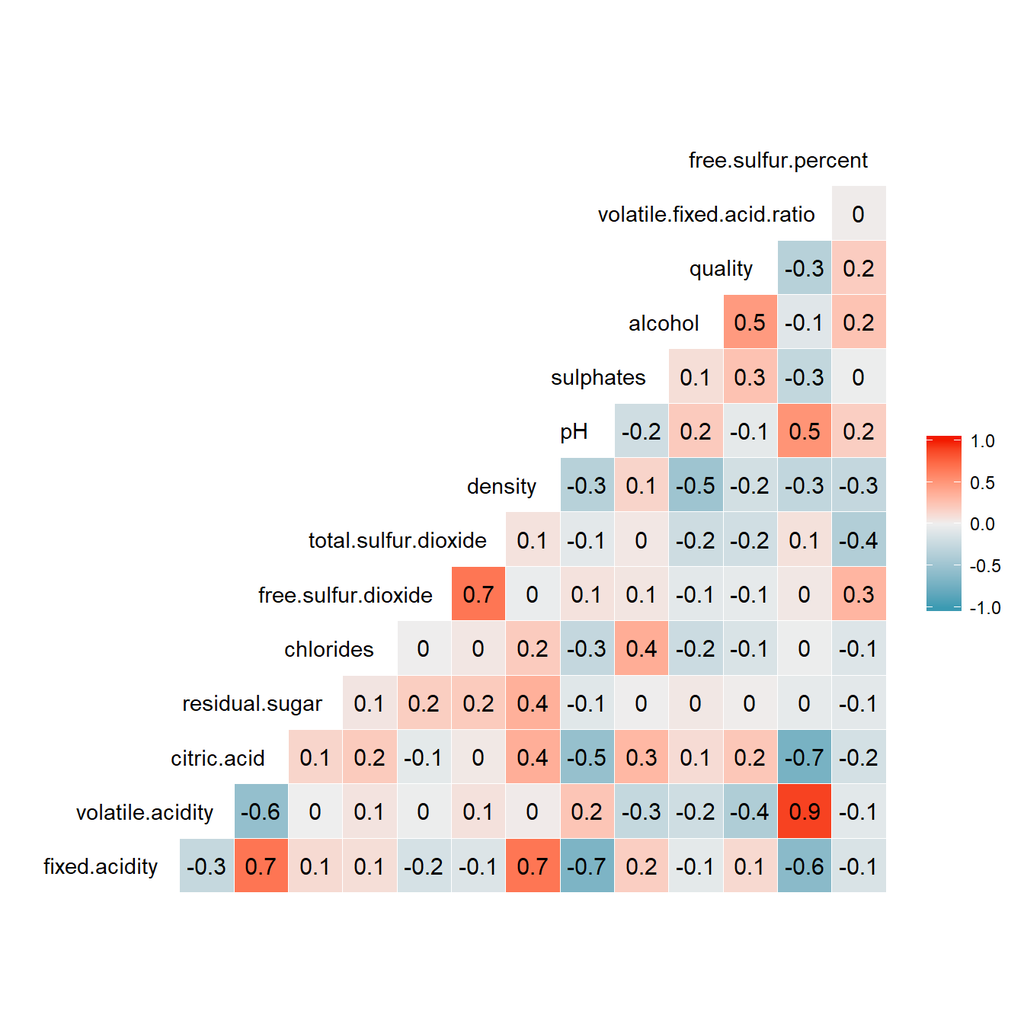

Let’s take a deeper look at some of the scatterplots. First I’m going to make a new variable for quality that turns it into a factor variable instead so I can make boxplots. I feel like boxplots will be visually easier to understand than scatterplots for certain quality plots because quality has integar values that are discrete

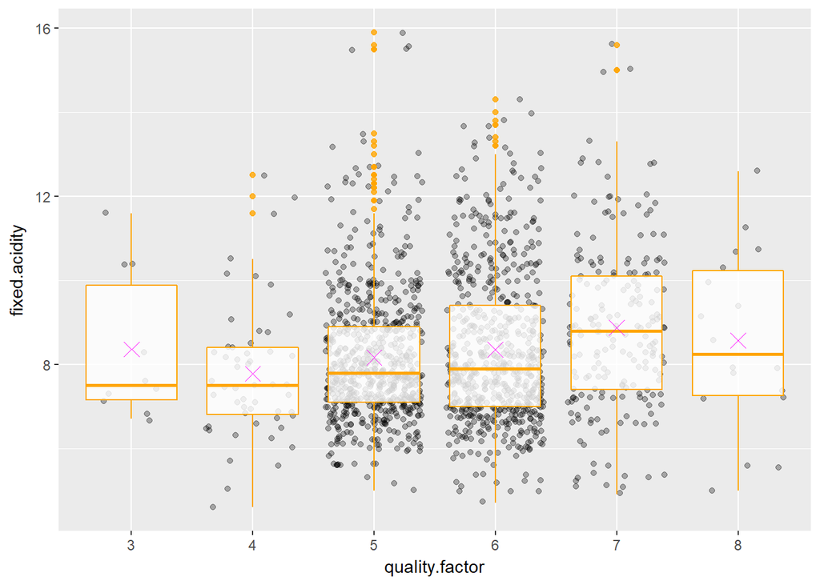

Fixed acidity seems to have an upward trend from 3 to 7 quality then dips back down for wines with quality 8. The variability also seems to increase except for quality 3. The X represents the mean. Seems that most of the values are skewed to the right as the mean is higher than the median.

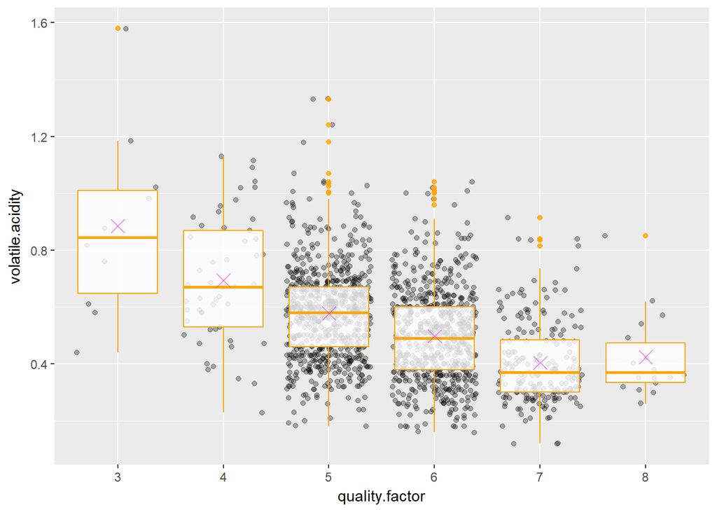

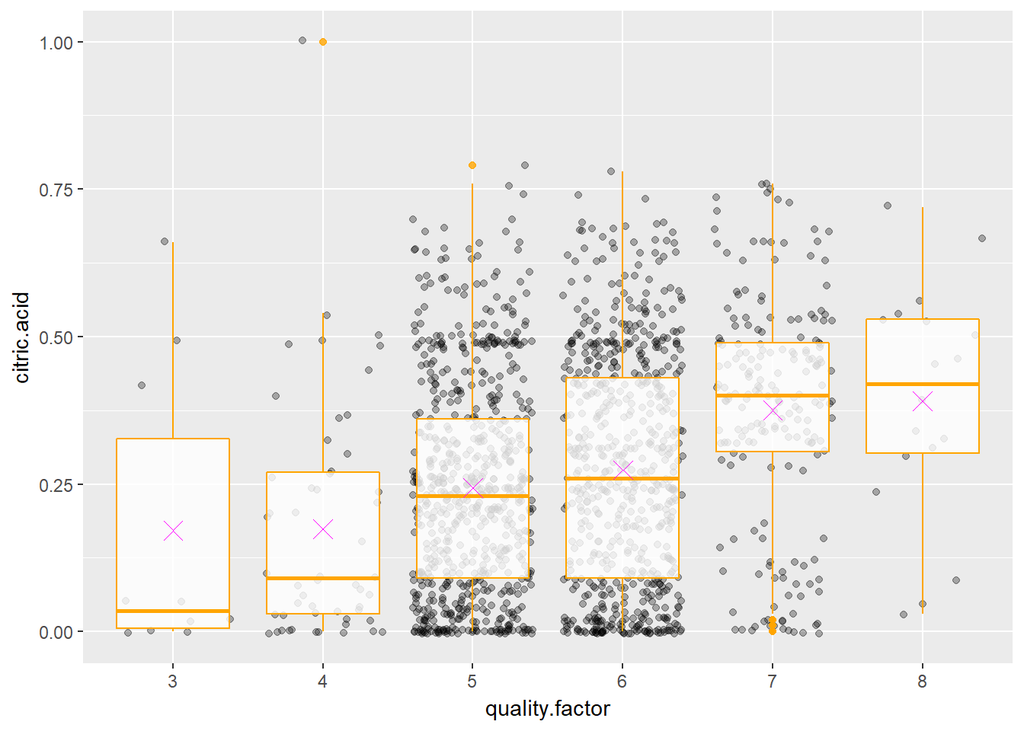

Quality definitely seems to increase as citric acid increases as expected. The variability seems to decrease as well but not uniformily. There are a couple of interesting outliers that don’t follow the general trend. Theres one wine that has 1 g/dm^3 of citric acid that is rated only 4 and a few with nearly 0 concentration of citric acid that were rated 7.

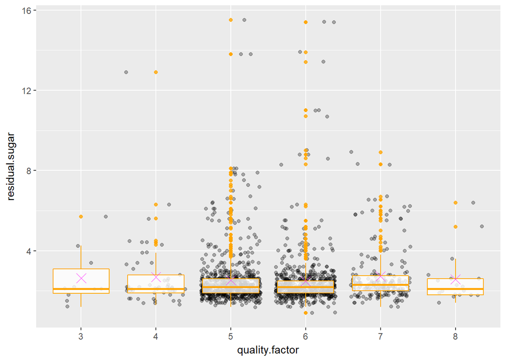

No obvious trends here. Correlation is .014 so I didn’t expect much either. Residual sugar is mildly correlated with density and denisty seems to have a low negative correlation with quality at -.175. I’ll look into this a little later.

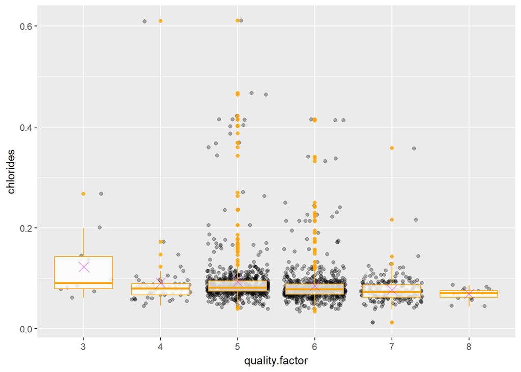

Chlorides doesn’t seem to have any visible trends on the boxplot. There are many outliers in quality 5 and 6.

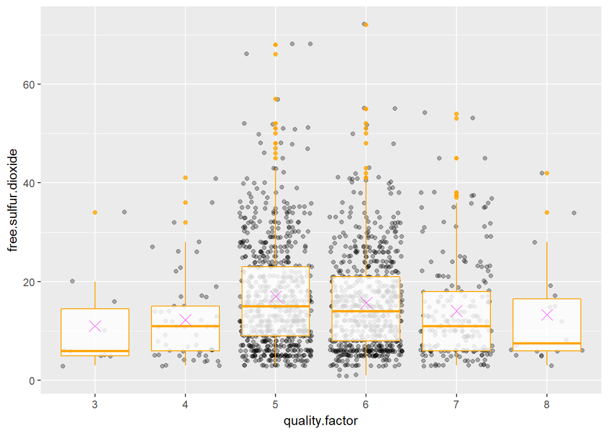

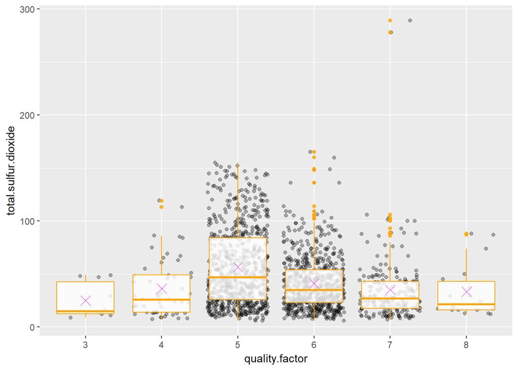

Free sulfur dioxide has an upward then downward trend as quality moves from 3 to 8. Variability seems to stay relatively the same with quality 5, 6 having the most outliers. Total sulfur dioxide seems to follow a similar trend with most outliers on quality 6 and 7. Quality 3 and 8 seem to have really similar boxplots for both free and total sulfur dioxide levels.

I think it’s important to note here that most of the observations in this dataset are of quality 5, 6, and 7. Quality 3, 4, and 8 only have 10, 53 and 18 observations each, respectively. I think it’s important to take this into account because finding any kind of trend going from quality 3 to 8 might be misleading since there is so little data in the lower and upper qualities. I think focusing on qualities 5, 6, and 7 to predict trends are the most important and reliable for this dataset.

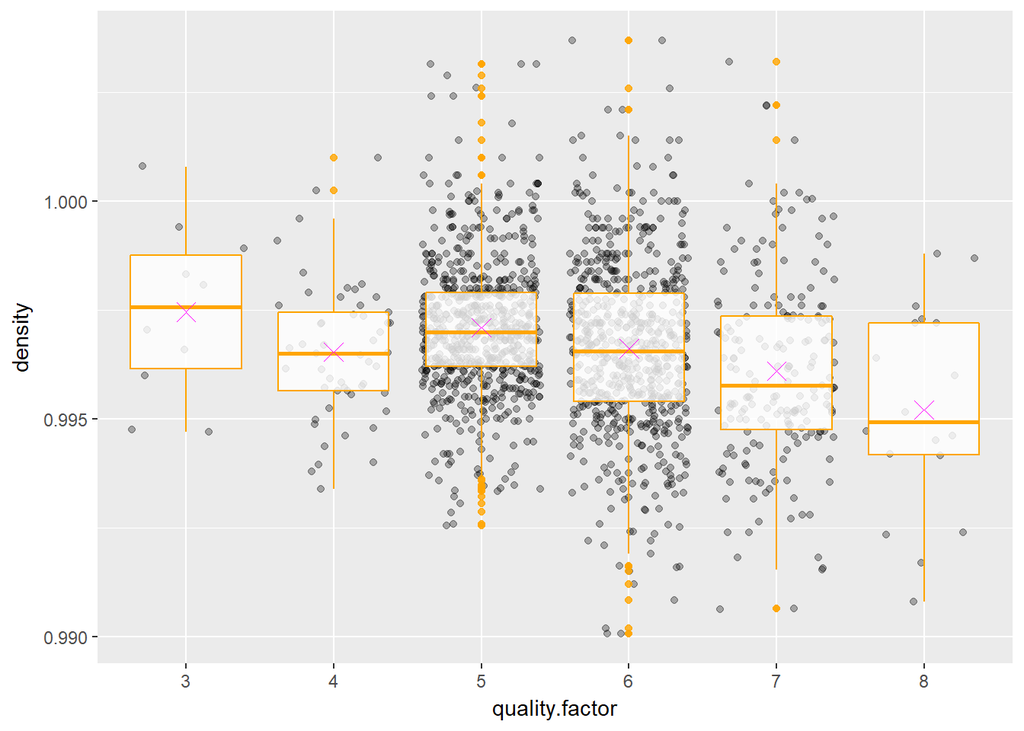

Denisty seems to have a downward trend as quality increases, however, variability also increases with that too. Denisty is correlated with fixed acidity, rsidual sugar, citric acid, and alcohol. Thist trend could be a byproduct of changes in levels of the above components of wine.

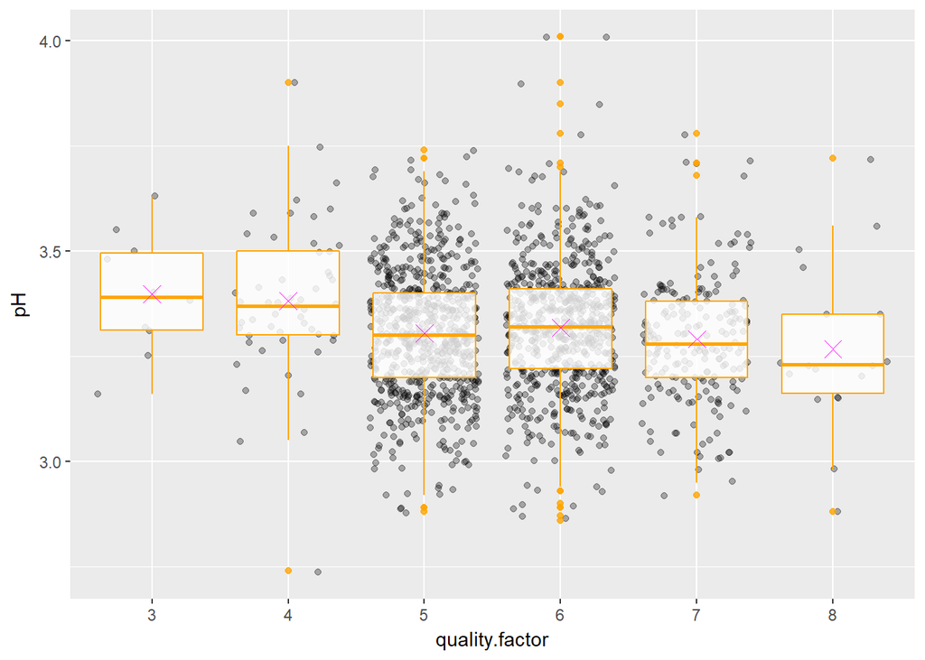

pH level also seems to have a slight downward trend, becoming more acid, as quality increases. Variability stays relatively the same with the most outliers at quality 6 and 7. pH level is strongly correlated with both free acidity, citric acid, as well as volatile to fixed acidity ratio. This trend is likely a byproduct of various acidity ratios in red wines.

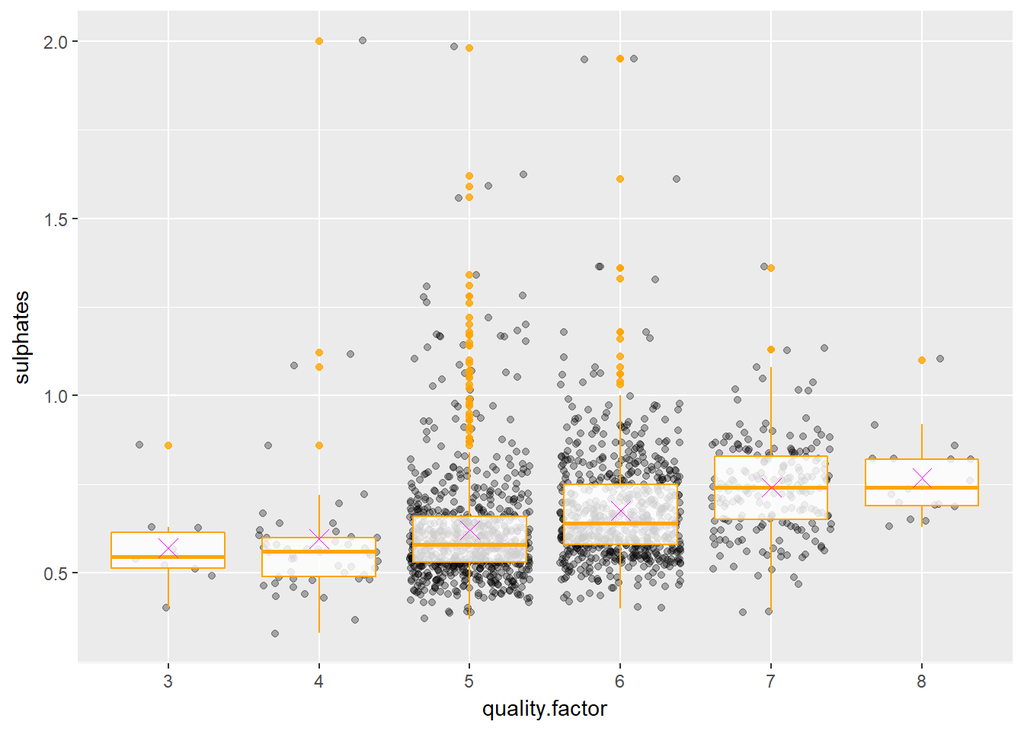

There is a clear upward trend. As quality increases, sulphates increase as well. This is interesting because it seems to contradict the plots for free and total sulfur dioxide as both those two plots had a downward trend in the higher qualities of wine. I’ll look more into this later.

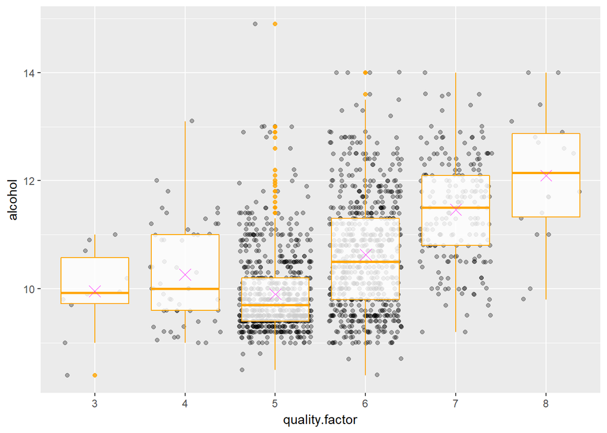

There’s also a very clear upward trend in alcohol content as quality goes up.